# NZ Election Data 2014

Nick Burns

Sunday, September 21, 2014

## Introduction

The 2014 New Zealand General Elections were held on September 20th, 2014.

7 PM Saturday night rolled around and we tuned the television into the live election broadcasts. The polls were closed and everyone was expecting a close fought battle between a hopeful Labour party and a beleaguered National party. Negative publicity around the DotCom scandal and the shadow of alleged dirty politics made it seem like if National were to cross the line, it would do so with a sever limp. Nobody predicted National’s landslide win which could see them in power without having to bend their knee to the smaller coalition parties. Along with the triumph was the drama of a defeated Labour, a less-than-popular leader in Cunliffe, the fall of “brand Dotcom”, a politically-impotent Winston Peters. All-in-all it has to be one the more dynamic and interesting elections New Zealand has experienced.

But despite all the hoo-ha, I didn’t wait up for the live results. Instead, I called it an early night and woke up early to start digging into the voting data! I have downloaded voting data from the New Zealand Electoral Commission and transformed and cleaned the dataset which is loaded as `data2014`. Let’s explore.

## Data2014

The data is a collection of voting data, categorised by Electorate. It includes 7 variables:  
- ID  
- Electorate  
- Party  
- PartyVotes  
- MPName  
- MPParty  
- MPVotes

And here is a summary of the data, the dataypes and the first 10 entries:

```r
summary(data2014)
```

```
##        ID                  Electorate
##  12     :  20   Epsom           :  20
##  46     :  19   Rongotai        :  19
##  1      :  18   Auckland Central:  18
##  8      :  18   Dunedin North   :  18
##  15     :  18   Helensville     :  18
##  27     :  18   Ikaroa-Rawhiti  :  18
##  (Other):1025   (Other)         :1025
##                               Party       PartyVotes
##                                  : 71   Min.   :    0
##  ACT New Zealand                 : 71   1st Qu.:   19
##  Aotearoa Legalise Cannabis Party: 71   Median :  128
##  Ban1080                         : 71   Mean   : 1974
##  Conservative                    : 71   3rd Qu.: 1901
##  Democrats for Social Credit     : 71   Max.   :21765
##  (Other)                         :710   NA's   :71
##                  MPName       MPParty       MPVotes
##                     :653          :653   Min.   :   11
##  ABRAHAM, George    :  1   LAB    : 71   1st Qu.:  206
##  ADAMS, Amy         :  1   CNSP   : 64   Median : 1285
##  ADCOCK-WHITE, Peter:  1   NAT    : 64   Mean   : 4322
##  AISH, Edward       :  1   GP     : 57   3rd Qu.: 6540
##  ALEXANDER, Glenda  :  1   ACT    : 39   Max.   :22657
##  (Other)            :478   (Other):188   NA's   :653
```

```r
str(data2014)
```

```
## 'data.frame':    1136 obs. of  7 variables:
##  $ ID        : Factor w/ 71 levels "1","2","3","4",..: 1 1 1 1 1 1 1 1 1 1 ...
##  $ Electorate: Factor w/ 71 levels "Auckland Central",..: 1 1 1 1 1 1 1 1 1 1 ...
##  $ Party     : Factor w/ 16 levels " ","ACT New Zealand",..: 10 2 1 8 3 6 9 13 15 12 ...
##  $ PartyVotes: int  4758 244 NA 4584 62 3 384 1187 12 9799 ...
##  $ MPName    : Factor w/ 484 levels " ","ABRAHAM, George",..: 9 211 308 360 1 1 1 1 1 197 ...
##  $ MPParty   : Factor w/ 25 levels " ","ACT","ALCP",..: 15 2 18 11 1 1 1 1 1 19 ...
##  $ MPVotes   : int  9393 142 12 1537 NA NA NA NA NA 10040 ...
```

```r
head(data2014, 10)
```

```
##    ID       Electorate                            Party PartyVotes
## 1   1 Auckland Central                     Labour Party       4758
## 2   1 Auckland Central                  ACT New Zealand        244
## 3   1 Auckland Central                                          NA
## 4   1 Auckland Central                      Green Party       4584
## 5   1 Auckland Central Aotearoa Legalise Cannabis Party         62
## 6   1 Auckland Central      Democrats for Social Credit          3
## 7   1 Auckland Central                    Internet MANA        384
## 8   1 Auckland Central          New Zealand First Party       1187
## 9   1 Auckland Central               The Civilian Party         12
## 10  1 Auckland Central                   National Party       9799
##              MPName MPParty MPVotes
## 1   ARDERN, Jacinda     LAB    9393
## 2  KOVALENKO, Dasha     ACT     142
## 3  OSMASTON, Jordan     MFP      12
## 4     ROCHE, Denise      GP    1537
## 5                                NA
## 6                                NA
## 7                                NA
## 8                                NA
## 9                                NA
## 10      KAYE, Nikki     NAT   10040
```

From the summary data, we can see that there are: - 71 unique IDs which correspond to 71 Electorates - a wide range of PartyVotes (min: 0, max: 21765, median: 128, mean: 1974) - and a wide range of MPVotes (min: 11, max: 22657, median: 1285, mean: 4322)

## Exploring the Data

The median and mode values for both PartyVotes and MPVotes suggest a strongly right-skewed distribution:

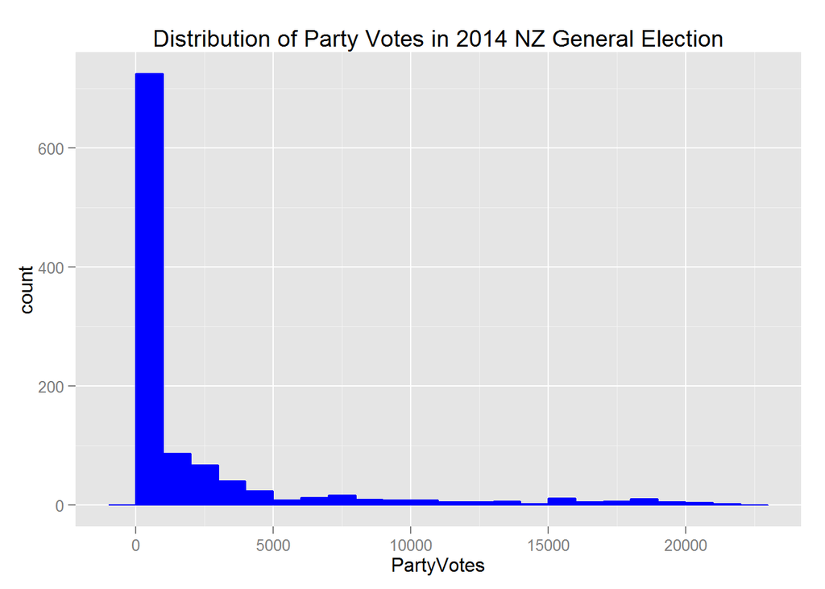

```r
ggplot(data2014, aes(x=PartyVotes)) +
  geom_histogram(stat="bin", colour="blue", fill="blue", binwidth=1000) +
  ggtitle("Distribution of Party Votes in 2014 NZ General Election")
```

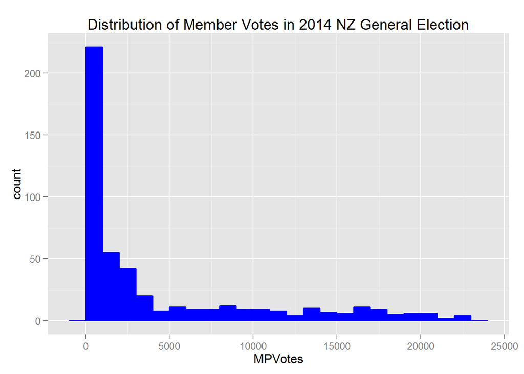

```r
ggplot(data2014, aes(x=MPVotes)) +
  geom_histogram(stat="bin", colour="blue", fill="blue", binwidth=1000) +
  ggtitle("Distribution of Member Votes in 2014 NZ General Election")
```

Let’s look at the winning parties in each electorate:

```r
# set the colour fill to match the party colours:
# party order: (ACT, Labour, Maori, National, United)
palette <- c("red", "blue")

party <- sqldf(
  "select d1.ID, d2.Party, max(d1.PartyVotes)
   from data2014 d1
     join data2014 d2
   where d1.ID = d2.ID
   group by d1.ID
   having d2.PartyVotes = max(d2.PartyVotes)"
  )
```

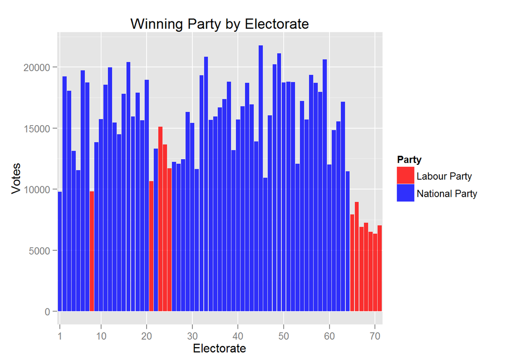

```r
names(party) <- c("Electorate", "Party", "Votes")

ggplot(party, aes(x=Electorate, y=Votes, fill=Party)) +
  geom_bar(stat="identity", alpha=0.8) +
  scale_fill_manual(values=palette) +
  ggtitle("Winning Party by Electorate") +
  scale_x_discrete(breaks = c(1, 10, 20, 30, 40, 50, 60, 70))
```

```r
  #theme(axis.text.x  = element_text(angle=90, vjust=0.5, size=6))
```

The plot above shows us that the National or Labour parties won the majority vote in all electorates. At first this was surprising, however this was verfified visually using The New Zealand Herald’s interactive application (http://data.nzherald.co.nz/electorates/). The interactive app confirmed that in all cases, the winning party was either National or Labour.

Competition for the second place was more varied. Again using the NZ Herald’s app, it became clear that where National won the party vote in any given electorate, there was more competition for second place with the Green Party and NZ First sometimes beating Labour into second place.

Let’s look at the winning members in each electorate:

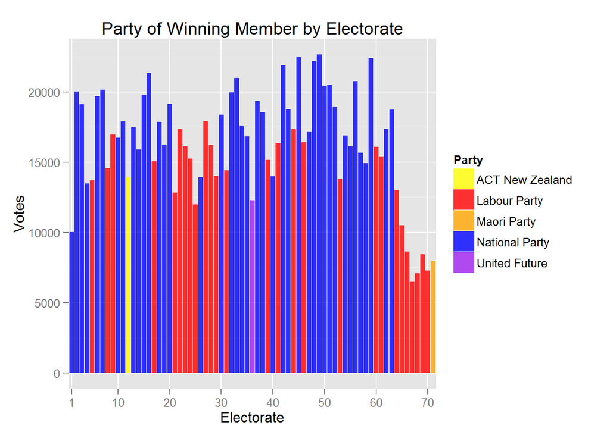

```r
palette <- c("yellow", "red", "orange", "blue", "purple")

member <- sqldf(
  "select d1.ID, d2.Party, max(d1.MPVotes)
   from data2014 d1
     join data2014 d2
   where d1.ID = d2.ID
   group by d1.Electorate
   having d2.MPVotes = max(d2.MPVotes)"
  )

names(member) <- c("Electorate", "Party", "Votes")

ggplot(member, aes(x=Electorate, y=Votes, fill=Party)) +
  geom_bar(stat="identity", alpha=0.8) +
  scale_fill_manual(values=palette) +
  ggtitle("Party of Winning Member by Electorate") +
  scale_x_discrete(breaks = c(1, 10, 20, 30, 40, 50, 60, 70))
```

```r
#theme(axis.text.x  = element_text(angle=90, vjust=0.5, size=8))
```

From the plot above we observe more diversity in the party of the winning member, compared to the winning party. There appears to be a more even distribution on National and Labour members as well as a single ACT, Maori Party and United Future member in three electorates.

We would expect there to be a strong correlation between members and parties receiving the majority vote in each electorate. Though perhaps overall the lack of diversity is surprising.